# Vehicle Fuel Economy - exploratory analysis

2018-11-11

# Introduction

In this post, we are going to look at some publicly available data to dig deeper into exploratory data analysis and machine learning techniques. I am going to start by fetching some data from the inter webs, this data is available at the [FuelEconomy.gov](http://www.fueleconomy.gov/feg/epadata/vehicles.csv.zip) site. This file has fuel economy data for all cars sold in the United States for several years.

We’ll try to load the file directly from the site. This allows us to get the most recent data from the internet.

```r
#temp <- tempfile()
#download.file("http://www.fueleconomy.gov/feg/epadata/vehicles.csv.zip", temp)
#unz(temp, "~/Downloads/vehicles.csv")
dt <- data.table::fread("~/Downloads/vehicles.csv", fill = TRUE)
#unlink(temp)
vehicles <- as_tibble(dt)
```

We have 40691 rows - that’s a lot of make and models.

Let’s take a look at what this data looks like using the excellent Skimr library for a succinct look.

```r
skim(vehicles)
```

```
Skim summary statistics
 n obs: 40691
 n variables: 83

── Variable type:character ─────────────────────────────────────────────────────────────────────────────────────────
   variable missing complete     n min max empty n_unique
    atvType       0    40691 40691   0  14 37219        9
  c240bDscr       0    40691 40691   0  19 40628        5
   c240Dscr       0    40691 40691   0  16 40626        6
  createdOn       0    40691 40691  28  28     0      247
      drive       0    40691 40691   0  26  1189        9
   eng_dscr       0    40691 40691   0  40 16034      556
    evMotor       0    40691 40691   0  51 39900      143
   fuelType       0    40691 40691   3  27     0       14
  fuelType1       0    40691 40691   6  17     0        6
  fuelType2       0    40691 40691   0  11 39108        5
    guzzler       0    40691 40691   0   1 38284        4
       make       0    40691 40691   3  34     0      135
    mfrCode       0    40691 40691   0   3 30818       48
      model       0    40691 40691   1  47     0     4018
 modifiedOn       0    40691 40691  28  28     0      120
    mpgData       0    40691 40691   1   1     0        2
     rangeA       0    40691 40691   0  11 39113      227
   sCharger       0    40691 40691   0   1 39874        2
  startStop       0    40691 40691   0   1 31704        3
   tCharger       0    40691 40691   0   1 34071        2
 trans_dscr       0    40691 40691   0  15 25644       53
      trany       0    40691 40691   0  32    11       38
     VClass       0    40691 40691   4  34     0       34

── Variable type:integer ───────────────────────────────────────────────────────────────────────────────────────────
     variable missing complete     n     mean       sd     p0     p25   p50     p75  p100     hist
       city08       0    40691 40691    18.27     7.5       6    15      17    20     150 ▇▁▁▁▁▁▁▁
      cityA08       0    40691 40691     0.64     4.92      0     0       0     0     145 ▇▁▁▁▁▁▁▁
          co2       0    40691 40691    84.95   172.88     -1    -1      -1    -1     847 ▇▁▁▁▁▁▁▁
         co2A       0    40691 40691     5.91    57.34     -1    -1      -1    -1     713 ▇▁▁▁▁▁▁▁
       comb08       0    40691 40691    20.52     7.32      7    17      20    23     136 ▇▂▁▁▁▁▁▁
      combA08       0    40691 40691     0.7      4.98      0     0       0     0     133 ▇▁▁▁▁▁▁▁
    cylinders     177    40514 40691     5.72     1.76      2     4       6     6      16 ▁▇▇▅▁▁▁▁
        engId       0    40691 40691  8255.07 17335.46      0     0     183  4216   69102 ▇▁▁▁▁▁▁▁
```

[output cut: 43 more lines]

```
      combinedUF       0    40691 40691   0.0014    0.027 0      0      0      0       0.89 ▇▁▁▁▁▁▁▁
           displ     175    40516 40691   3.3       1.36  0      2.2    3      4.3     8.4  ▁▆▇▅▃▃▁▁
      highway08U       0    40691 40691   7.6      13.52  0      0      0     19.01  123.34 ▇▂▁▁▁▁▁▁
     highwayA08U       0    40691 40691   0.6       4.93  0      0      0      0     121.2  ▇▁▁▁▁▁▁▁
       highwayCD       0    40691 40691   0.00024   0.029 0      0      0      0       4.06 ▇▁▁▁▁▁▁▁
        highwayE       0    40691 40691   0.3       3.7   0      0      0      0     120    ▇▁▁▁▁▁▁▁
       highwayUF       0    40691 40691   0.0013    0.026 0      0      0      0       0.88 ▇▁▁▁▁▁▁▁
       rangeCity       0    40691 40691   0.6      11.19  0      0      0      0     333.11 ▇▁▁▁▁▁▁▁
      rangeCityA       0    40691 40691   0.073     1.69  0      0      0      0     103.03 ▇▁▁▁▁▁▁▁
        rangeHwy       0    40691 40691   0.58     11.19  0      0      0      0     346.9  ▇▁▁▁▁▁▁▁
       rangeHwyA       0    40691 40691   0.067     1.52  0      0      0      0      90.55 ▇▁▁▁▁▁▁▁
           UCity       0    40691 40691  23.06     10.63  0     18.18  21.32  25.8   224.8  ▇▂▁▁▁▁▁▁
          UCityA       0    40691 40691   0.82      6.88  0      0      0      0     207.26 ▇▁▁▁▁▁▁▁
        UHighway       0    40691 40691  34.2      10.88  0     27.79  33.15  39     182.7  ▁▇▁▁▁▁▁▁
       UHighwayA       0    40691 40691   1.1       7.42  0      0      0      0     173.14 ▇▁▁▁▁▁▁▁
```

# Data Exploration

Let’s start the data exploration by looking at how many vehicles were added in each year. Before we start, I like to use a common theme for ggplot in the document, add that first.

```r
# Global document theme
theme_glob <- theme_bw(base_family="Helvetica", base_size = 12) +
    theme(axis.text.x = element_text(angle = 45, vjust = 1, hjust = 1), legend.direction = "horizontal", legend.position = "top")
theme_set(theme_glob)
```

## Vehicles and Years

How many models are released per year?

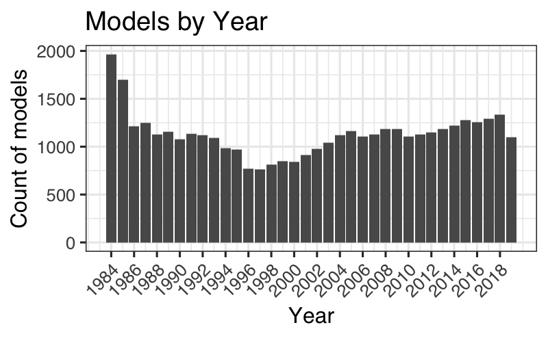

```r
# Add some extra information for later use
vehicles <- vehicles %>%
  mutate(fuelType_f = gsub(fuelType1, pattern = regex('.*Gasoline', ignore_case = TRUE), replacement = 'Gasoline'))
current_model_year <- max(vehicles$year)
vehicles %>%
  ggplot(aes(x=year)) +
  geom_bar( aes(fill = year), stat = "count", show.legend = FALSE) +
  labs(title = "Models by Year", y = "Count of models", x = "Year") +
  scale_x_continuous(breaks =  seq( min(vehicles$year), max(vehicles$year), by = 2) )
```

## Vehicles and Manufacturers

How many manufacturers do we have? We have 135 total number of manufacturers in our list. Here are the top 20.

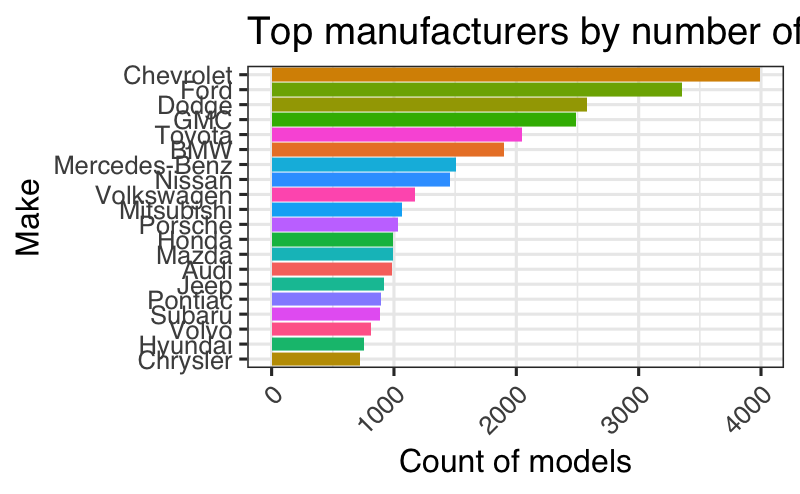

```r
vehicles %>%
  count(make) %>%
  top_n(20, wt = n ) %>%

  ggplot(aes(x = reorder(make, n), y = n )) +
  geom_bar( aes(fill = make), stat = "identity", show.legend = FALSE) +
    labs(title = "Top manufacturers by number of models", y = "Count of models", x = "Make") +
  coord_flip()
```

WTF, Chevrolet has close to 4000 models - this is not a real number because each manufacturer (make) has the same model coming back in a different year. We will need to identify truly unique models.

| make | model | n |
| --- | --- | --- |
| Acura | 2.2CL/3.0CL | 3 |
| Acura | 2.3CL/3.0CL | 6 |
| Acura | 2.5TL | 1 |
| Acura | 2.5TL/3.2TL | 6 |
| Acura | 3.2CL | 4 |
| Acura | 3.2TL | 5 |
| Acura | 3.5RL | 9 |
| Acura | ILX | 10 |
| Acura | ILX Hybrid | 2 |
| Acura | Integra | 42 |

[output cut: 990 more lines]

# Fuel Economy

Let’s dive into an analysis of fuel economy and see how things have changed over the year, clearly economy has gone up but seems to have suffered recently. We will try and investigate why that happened. The other issue is that this data contains other types of alternative fuels, we need to adjust for different fuel types.

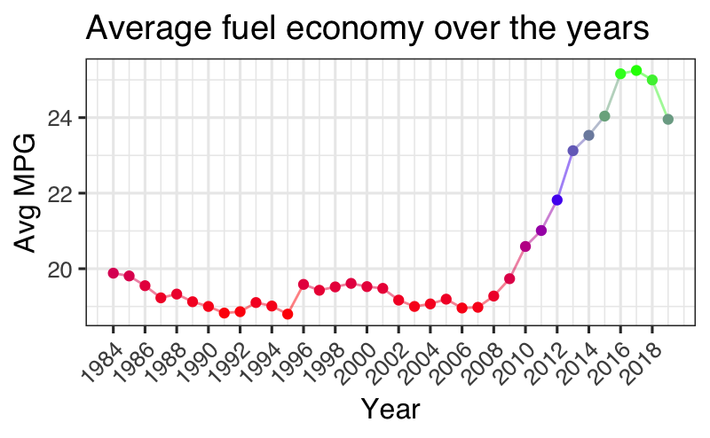

```r
vehicles %>%
  group_by(year) %>%
  summarise(avgMPG = mean(comb08)) %>%
  ggplot(aes(x=year, y = avgMPG)) +
  geom_line(aes(color = avgMPG), alpha = 0.5, show.legend = FALSE) +
  geom_point(aes(color = avgMPG), show.legend = FALSE) +
  scale_x_continuous(breaks =  seq( min(vehicles$year), max(vehicles$year), by = 2) ) +
  scale_color_gradientn(colours=c("red", "blue", "green")) +
  labs(title = "Average fuel economy over the years", y = "Avg MPG", x = "Year")
```

```r
NA
```

## By Fuel type

Let’s look at the vehicles by the type of fuel - we had previously added an additional column that describes the different fuel types for these vehicles. Clearly, electric powered vehicles have an edge over other forms of fuel.

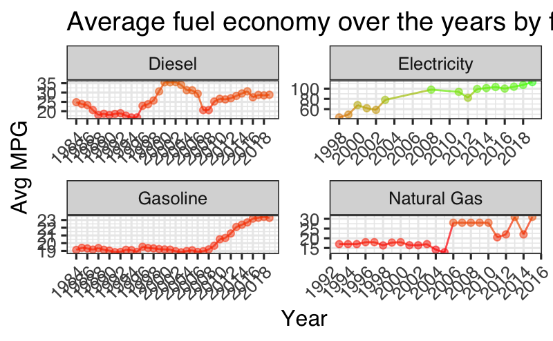

```r
vehicles %>%
  group_by(year, fuelType_f) %>%
  summarise(avgMPG = mean(comb08)) %>%
  ggplot(aes(x=year, y = avgMPG)) +
  geom_line(aes(color = avgMPG), alpha = 0.7, show.legend = FALSE) +
  geom_point(aes(color = avgMPG), alpha = 0.5, show.legend = FALSE) +
  scale_x_continuous(breaks =  seq( min(vehicles$year), max(vehicles$year), by = 2) ) +
  scale_color_gradientn(colours=c("red", "green")) +
  labs(title = "Average fuel economy over the years by fuel type", y = "Avg MPG", x = "Year") +
  facet_wrap(~ fuelType_f, scales = "free")
```

## By Vehicle class

For this we will limit ourselves to Gasoline fueled vehicles since not all vehicles are made equal, let’s also try and see how different vehicle classes score.

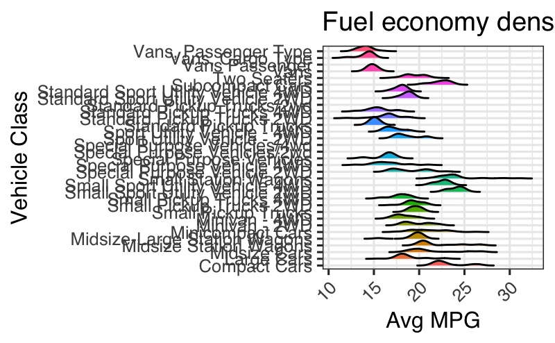

```r
vehicles %>%
  filter(fuelType_f == 'Gasoline') %>%
  group_by(year, VClass) %>%
  summarise(avgMPG = mean(comb08)) %>%
  ggplot() +
  geom_density_ridges(aes(x = avgMPG, y = as.factor(VClass), fill = VClass), rel_min_height = 0.001, scale = 1, show.legend = FALSE) +
  labs(title = "Fuel economy density by Vehicle class", y = "Vehicle Class", x = "Avg MPG")
```

It’s clear that we are comparing apples to oranges - let’s roll up the data to create some vehicle classes and try this again.

```r
vehicles <- vehicles %>%
  mutate(VClass_f = case_when(str_detect(VClass, pattern = "Trucks") ~ "Pickup Trucks",
                              str_detect(VClass, pattern = "Cars|Wagons") ~ "Cars",
                              str_detect(VClass, pattern = "Sport") ~ "SUV",
                              str_detect(VClass, pattern = regex("van", ignore_case = TRUE) ) ~ "Vans",
                              TRUE ~ "Other"))
```

We can start to see the range of mpg averages over the different vehicle classes. This graph represents the density (relative proportions) of mpg ratings in each vehicle class.

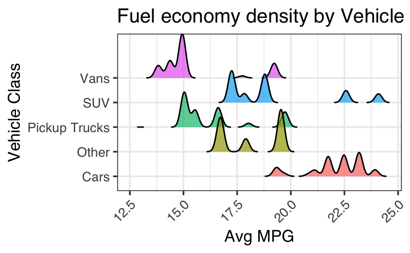

```r
vehicles %>%
  filter(fuelType_f == 'Gasoline' , fuelType2 != "Electricity") %>%
  group_by( VClass) %>%
  mutate(avgMPG = mean(comb08)) %>% ungroup() %>%
  ggplot(aes(x = avgMPG, y = as.factor(VClass_f))) +
  geom_density_ridges(aes(fill = VClass_f), rel_min_height = 0.001, show.legend = FALSE, alpha = 0.7) +
  labs(title = "Fuel economy density by Vehicle class", y = "Vehicle Class", x = "Avg MPG")
```

```r
NA
```

Let’s see what kind of engine displacements we are talking about in this set. It’s clear that there is a correlation between displacement and fuel economy. We will explore that later.

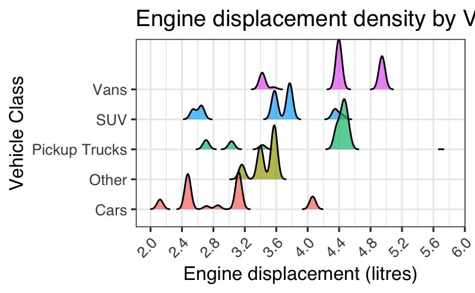

```r
vehicles %>%
  filter(fuelType_f == 'Gasoline', fuelType2 != "Electricity") %>%
  group_by( VClass) %>%
  mutate(avgDispl = mean(displ)) %>% ungroup() %>%
  ggplot(aes(x = avgDispl, y = as.factor(VClass_f))) +
  geom_density_ridges(aes(fill = VClass_f), rel_min_height = 0.001, show.legend = FALSE, alpha = 0.7) +
  labs(title = "Engine displacement density by Vehicle class", y = "Vehicle Class", x = "Engine displacement (litres)") +
  scale_x_continuous(breaks = seq(1.6,6, by = 0.4))
```

## Engine displacement vs fuel economy

- Not including plug-in hybrids.

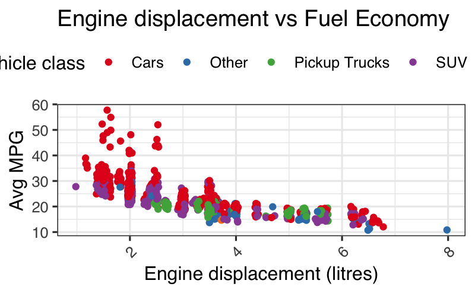

```r
vehicles %>%
  filter(fuelType_f == 'Gasoline' , fuelType2 != "Electricity", year == current_model_year) %>%
  ggplot(aes(y=comb08, x = displ)) +
  geom_point(aes(color = VClass_f, group = VClass_f), position = "jitter",  na.rm = TRUE ) +
  scale_color_brewer(palette = "Set1") +
  labs(title = "Engine displacement vs Fuel Economy", y = "Avg MPG", x = "Engine displacement (litres)") +
  guides(color = guide_legend(title="Vehicle class"))
```

Let’s also see how has economy improved over the years for each of these segments; cars and Vans have had the most improvement over time and SUVs are a relatively new segment and were only defined near 2000. The second chart shows the relative numbers of models in each class.

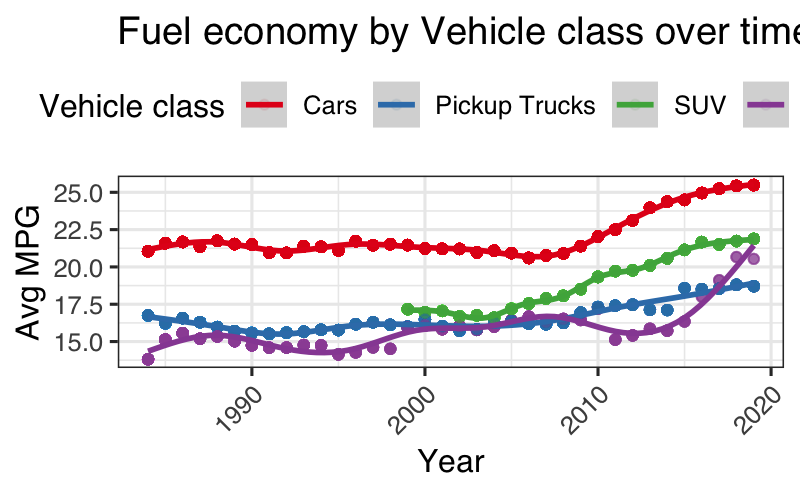

```r
vehicles %>%
  filter(fuelType_f == 'Gasoline',VClass_f != "Other") %>%
  group_by(year, VClass_f) %>%
  mutate(avgMPG = mean(comb08)) %>%
  ungroup() %>%
  ggplot(aes(x = year, y = avgMPG)) +
  geom_point(aes(color = VClass_f), alpha = 0.1) +
  geom_smooth(aes(color = VClass_f))  +
  labs(title = "Fuel economy by Vehicle class over time", y = "Avg MPG", x = "Year") +
  guides(color = guide_legend(title="Vehicle class")) +
  scale_color_brewer(palette = "Set1")
```

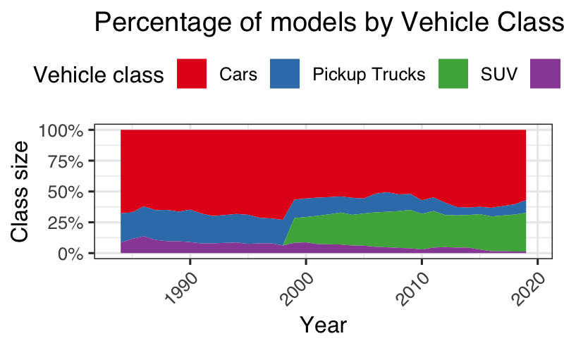

```r
vehicles %>%
  filter(fuelType_f == 'Gasoline',VClass_f != "Other") %>%
  group_by(year, VClass_f) %>%
  ungroup() %>%
  ggplot(aes(x = year, y = ..count..)) +
  geom_area(aes(fill = VClass_f), stat= "bin", position = "fill", binwidth = 1) +
  labs(title = "Percentage of models by Vehicle Class (Gasoline only)", y = "Class size", x = "Year") +
  guides(fill = guide_legend(title="Vehicle class")) +
  scale_y_continuous(labels = scales::percent, breaks = seq(0,1, by = .25)) +
  scale_fill_brewer(palette = "Set1")
```

## By manufacturers

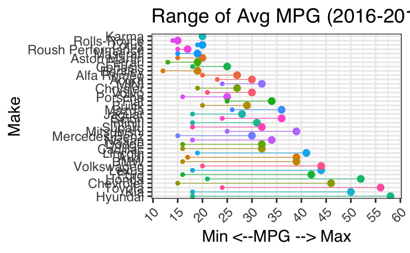

```r
vehicles %>%
  filter(fuelType_f == 'Gasoline',VClass_f == "Cars", between(year, current_model_year-3, current_model_year)) %>%
  group_by(make) %>%
  summarise(min = min(comb08), max = max(comb08)) %>%

  ggplot() +
    geom_point(aes(x = reorder(make, -(max - min), order = TRUE ), y = max, color = make), size = 2, show.legend = FALSE)  +
    geom_point(aes(x = make, y = min, color = make), size = 1, show.legend = FALSE) +
    geom_segment(aes(x = make, xend = make, y = min, yend = max, color = make), size = 0.2, show.legend = FALSE) +
    coord_flip() +
    scale_y_continuous(breaks = seq(10,60, by = 5)) +
    labs(title = paste0("Range of Avg MPG (", current_model_year -3, "-", current_model_year, " models)"), x = "Make", y = "Min <--MPG --> Max")
```

## Most Improved

My goal here is to find the most fuel efficient vehicles. There are many ways to slice this data to find the best vehicles; by make, by vehicle class, by fuel type, by engine size, seating capacity and many other ways. One interesting metric would be to see which models have the most improved efficiency over time. We will find vehicles that are still being sold in the current model year and have been around for at least three model years. Once more, we’ll limit our set to Gasoline powered vehicles only. The chart below shows the most improved and ones that have gotten much worse over the years.

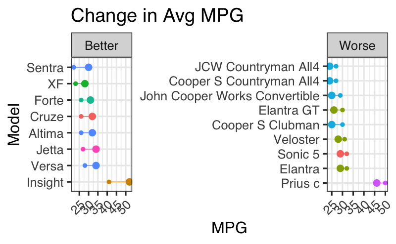

```r
# Find models that are still being sold in the current model year
vehicles %>%
  filter(year == 2019, fuelType_f == "Gasoline", VClass_f == "Cars") %>%
  distinct(make, model, fuelType_f, trany, fuelType, cylinders) %>%
  inner_join(vehicles, by = c("make", "model", "trany", "fuelType", "cylinders")) %>%
  group_by(make, model, trany, fuelType, cylinders) %>%
  summarise(years_sold = n_distinct(year), mpg_start = comb08[which.min(year)], mpg_end = comb08[which.max(year)], mpg_range = mpg_end - mpg_start, min_year = year[which.min(year)], max_year = year[which.max(year)]) %>%
  ungroup() %>%
  mutate(avg_range = mean(mpg_range), sd_range = sd(mpg_range), shift = if_else(mpg_range > 0, "Better", "Worse")) %>%
  filter(years_sold > 2, mpg_range > 3 * sd_range | mpg_range < -2* sd_range) %>%

  ggplot() +
    geom_point(aes(x = reorder(model, -mpg_start), y = mpg_end, color = make), size = 2, show.legend = FALSE) +
    geom_point(aes(x = model, y = mpg_start, color = make), size = 1 , show.legend = FALSE) +
    geom_segment(aes(x = model, xend = model, y = mpg_start, yend = if_else(shift == "Better", mpg_end -0.65, mpg_end + 0.65), color = make), linejoin = "mitre", arrow = arrow(length = unit(0.03, "npc"), type = "closed"), size = 0.2, show.legend = FALSE) +
    geom_text_repel(aes(x = model, y = mpg_start, label = min_year), size = 2.5 ) +
    scale_y_continuous(breaks = seq(10,60, by = 5)) +
    labs(title ="Change in Avg MPG", x = "Model", y = "MPG") +
    facet_wrap(~shift, scales = "free") +
  coord_flip()
```

## Most fuel efficient Models in class

Let’s look at the real fuel sippers by class of vehicle - we’ll start by the larger class and then refine further into smaller sub-classes. All these are the most recent models and all are Gasoline powered. We will look at other fuel types separately.

### By Vehicle class

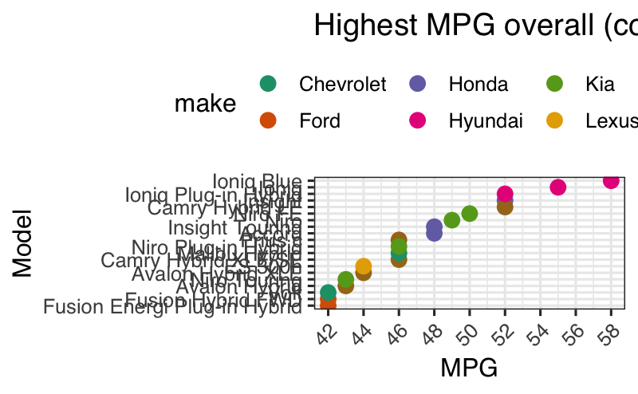

```r
vehicles %>%
  filter(year == current_model_year, fuelType_f == "Gasoline") %>%
  top_n(20, wt = comb08) %>%
  ggplot() +
  geom_point(aes(x = reorder(model, comb08), y = comb08, color = make), size = 3) +

  coord_flip() +
  labs(title ="Highest MPG overall (combined)", x = "Model", y = "MPG") +
  scale_y_continuous(breaks = seq(30,60, by = 2)) +
  scale_color_brewer(palette = "Dark2")
```

### By Vehicle type

Since SUVs and Cars are the biggest segments - let’s limit to those. Only look for full gasoline or hybrid vehicles, exclude any plug in hybrids

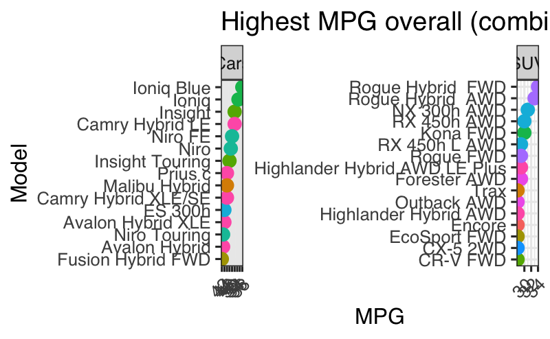

```r
vehicles %>%
  filter(year == current_model_year, fuelType_f == "Gasoline", fuelType2 != "Electricity", VClass_f %in% c("Cars", "SUV")) %>%
  group_by(VClass_f) %>%
  distinct(model, .keep_all = TRUE) %>%
  top_n(15, wt = comb08) %>%
  ggplot() +
  geom_point(aes(x = reorder(model, comb08), y = comb08, color = make), size = 3, show.legend = FALSE) +

  coord_flip() +
  labs(title ="Highest MPG overall (combined)", x = "Model", y = "MPG") +
  scale_y_continuous(breaks = seq(30,60, by = 2)) +
  #scale_color_brewer(palette = "Dark2") +
  facet_wrap(~ VClass_f, scales ="free")
```

Before we move on, let’s take a quick look at the worst overall MPG

### Worst MPG

Gasoline Cars - current model year Looking at this, at least Rolls Royce is constiently bad across most of it’s models and Grand Cherokee Trackhawk is a 800 bhp, 0 - 60 in less than 3 second beast.

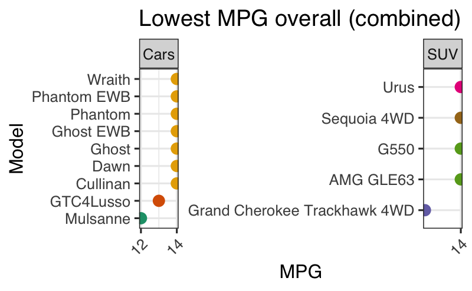

```r
vehicles %>%
  filter(year == current_model_year, fuelType_f == "Gasoline", fuelType2 != "Electricity", VClass_f %in% c("Cars", "SUV")) %>%
  group_by(VClass_f) %>%
  distinct(model, .keep_all = TRUE) %>%
  top_n(5, wt = -comb08) %>%
  ggplot() +
  geom_point(aes(x = reorder(model, comb08), y = comb08, color = make), size = 3, show.legend = FALSE) +

  coord_flip() +
  labs(title ="Lowest MPG overall (combined)", x = "Model", y = "MPG") +
  scale_y_continuous(breaks = seq(0,20, by = 2)) +
  scale_color_brewer(palette = "Dark2") +
  facet_wrap(~ VClass_f, scales ="free")
```

## Electric Vehicles

Before looking at the data, a quick look a the number of models for each fuel type

### Different Fuel Types

- Current model year only

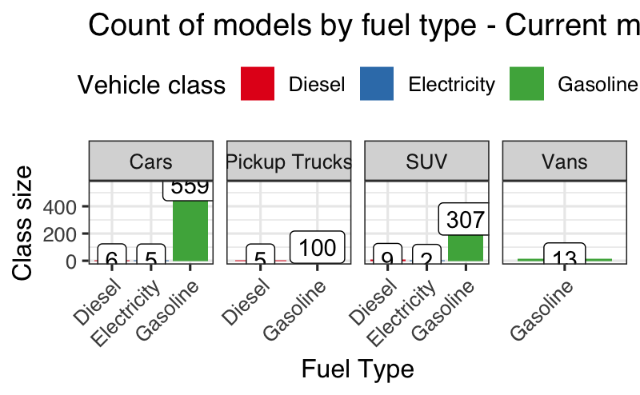

```r
vehicles %>%
  filter(year == current_model_year, VClass_f != "Other") %>%
  group_by(fuelType_f) %>%
  ggplot(aes( x = fuelType_f)) +
  geom_bar(aes(fill = fuelType_f)) +
  scale_fill_brewer(palette = "Set1") +
  facet_grid(~ VClass_f, scales = "free") +
  labs(title = "Count of models by fuel type - Current model year", y = "Class size", x = "Fuel Type") +
  guides(fill = guide_legend(title="Vehicle class")) +
  geom_label(stat = "count", aes(label = ..count.., y = ..count..))
```

```r
NA
```

While EVs are still an extremely small segment of the total passenger vehicle segment, they are certainly starting to be noticed. Let’s look at the electric vehicle stats before we move to some machine learning.

### Electric Effciency

We’ll look at the transitional electric vehicles first - these are also called the plug-in electric vehicles where they retain an IC engine along with some battery.

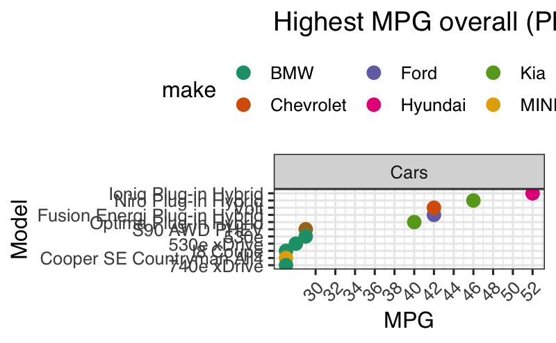

```r
vehicles %>%
  filter(fuelType2 == "Electricity", year == current_model_year , VClass_f %in% c("Cars")) %>%
  group_by(VClass_f) %>%
  distinct(model, .keep_all = TRUE) %>%
  top_n(15, wt = comb08) %>%
  ggplot() +
  geom_point(aes(x = reorder(model, comb08), y = comb08, color = make), size = 3) +

  coord_flip() +
  labs(title ="Highest MPG overall (Plug in hybrids)", x = "Model", y = "MPG") +
  scale_y_continuous(breaks = seq(30,60, by = 2)) +
  scale_color_brewer(palette = "Dark2") +
  facet_wrap(~ VClass_f, scales ="free")
```

### Fully electric

Hyundai seems to have taken the top spots in both the Cars and SUV segments and Tesla is doing well in both segments.

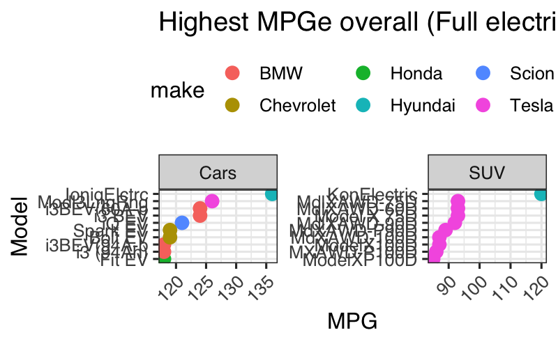

```r
vehicles %>%
  filter(fuelType_f == "Electricity",  VClass_f %in% c("Cars", "SUV")) %>%
  group_by(VClass_f) %>%
  distinct(model, .keep_all = TRUE) %>%
  top_n(10, wt = comb08) %>%
  ggplot() +
  geom_point(aes(x = reorder(model, comb08), y = comb08, color = make), size = 3) +

  coord_flip() +
  labs(title ="Highest MPGe overall (Full electric)", x = "Model", y = "MPG") +
  facet_wrap(~ VClass_f, scales ="free") +
  scale_x_discrete(labels = function(x) abbreviate(x, minlength = 11L))
```

### Fully electric range

What kind of range do we get at the top of the heap and it’s clear that Tesla has done a phenomenal job both in efficiency and range.

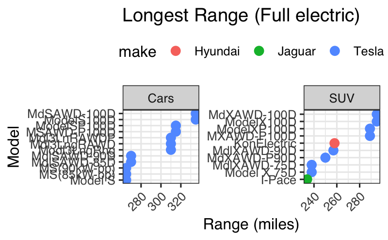

```r
vehicles %>%
  filter(fuelType_f == "Electricity", VClass_f %in% c("Cars", "SUV")) %>%
  group_by(VClass_f) %>%
  distinct(model, .keep_all = TRUE) %>%
  top_n(10, wt = range) %>%
  ggplot() +
  geom_point(aes(x = reorder(model, range), y = range, color = make), size = 3) +

  coord_flip() +
  labs(title ="Longest Range (Full electric)", x = "Model", y = "Range (miles)") +
  facet_wrap(~ VClass_f, scales ="free") +
  scale_x_discrete(labels = function(x) abbreviate(x, minlength = 11L))
```

# Machine Learning

This is a great dataset to try and dig into machine learning. Start with some clustering

## Clustering

Clustering is process of grouping together similar items. In this case we want to see which vehicles are most like another and form groups.

Before we get into the actual clustering, we’ll try and identify which variables are related and which are ones that are important. We’ll use a technique called Principal Component Analysis. Let’s take a look at what the data looks like; some of these are clearly propotinally and linearly related, while others have some more spread out variations.

```r
data <- vehicles %>%
  filter(year == current_model_year, fuelType_f == "Gasoline", fuelType2 != "Electricity",  VClass_f == "Cars") %>%
  distinct( model,  trany,  cylinders, .keep_all = TRUE) %>%
  mutate(model = paste(model, trany, cylinders, sep = "-")) %>%
  select(model, barrels08, co2TailpipeGpm, comb08, cylinders, displ, fuelCost08, highway08, city08, youSaveSpend)

data <- na.omit(data)
rownames(data) <- data$model
```

```
Setting row names on a tibble is deprecated.
```

[figure not shown]

```r
data <- select(data, -model)
data <- as.data.frame(data)
plot(data)
```

Before we run the principal components, we’ll scale the data to normalize it - that will ensure that the data ranges are normalized and one single element does not have a large range and does not dominate.

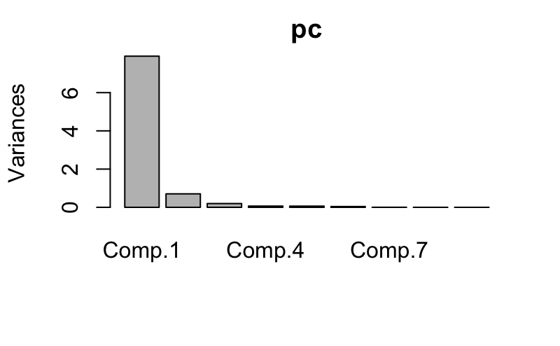

```r
df <- scale(data)
pc <- princomp(df)
plot(pc)
```

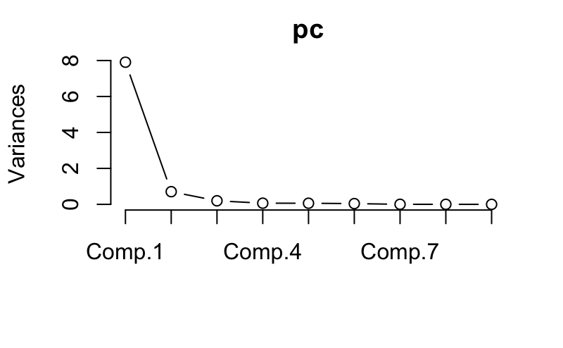

```r
plot(pc, type='l')
```

```r
summary(pc)
```

```
Importance of components:
                         Comp.1     Comp.2     Comp.3    Comp.4      Comp.5      Comp.6       Comp.7       Comp.8
Standard deviation     2.812022 0.83975270 0.44481614 0.2540906 0.249338199 0.203219368 0.0560124163 2.721122e-02
Proportion of Variance 0.880327 0.07850718 0.02202762 0.0071876 0.006921244 0.004597659 0.0003492812 8.243325e-05
Cumulative Proportion  0.880327 0.95883416 0.98086178 0.9880494 0.994970627 0.999568286 0.9999175667 1.000000e+00
                       Comp.9
Standard deviation          0
Proportion of Variance      0
Cumulative Proportion       1
```

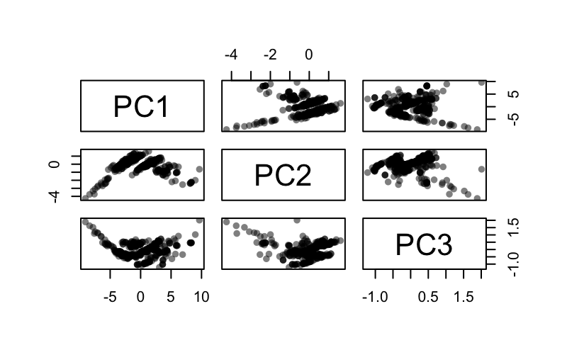

```r
pc <- prcomp(df)
comp <- data.frame(pc$x[,1:3])
# Plot
plot(comp, pch=16, col=rgb(0,0,0,0.5))
```

### K-means

One of the first things we need to identify is an optimum number of clusters we should seek. Here I used the code from [R in Action](http://www.statmethods.net/advstats/cluster.html):

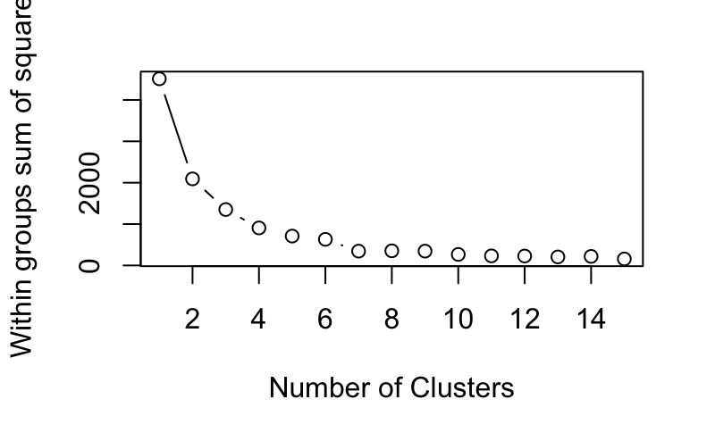

```r
# Determine number of clusters
wss <- (nrow(comp)-1)*sum(apply(comp,2,var))
for (i in 2:15) wss[i] <- sum(kmeans(comp,
                                     centers=i)$withinss)
plot(1:15, wss, type="b", xlab="Number of Clusters",
     ylab="Within groups sum of squares")
```

Based on the scree plot above, let’s go with 5 clusters within this data.

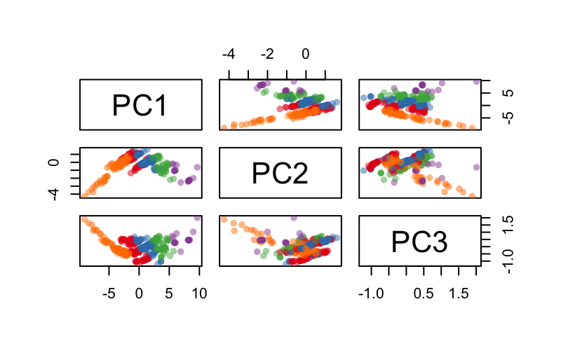

```r
# Only do this for gasoline cars initially
set.seed(1215)
k <- kmeans(data, 5, nstart=25, iter.max=1000)
palette(alpha(brewer.pal(9,'Set1'), 0.5))
plot(comp, col=k$clust, pch=16)
```

Finally, we can identify the vehicles that have been clustered together.

```r
clust <- names(table(k$clust))
# First cluster
map(clust, function(x) {
  row.names(data[k$clust==x,])
})
```

```
[[1]]
  [1] "TLX FWD A-SPEC-Automatic (AM-S8)-4"              "Cooper Convertible-Automatic (S6)-3"
  [3] "Cooper Convertible-Manual 6-spd-3"               "Cooper S Convertible-Automatic (S6)-4"
  [5] "Cooper S Convertible-Manual 6-spd-4"             "John Cooper Works Convertible-Automatic (S6)-4"
  [7] "430i Convertible-Automatic (S8)-4"               "430i xDrive Convertible-Automatic (S8)-4"
  [9] "Cooper Hardtop 2 door-Automatic (S6)-3"          "Cooper Hardtop 2 door-Manual 6-spd-3"
 [11] "Cooper Hardtop 4 door-Automatic (S6)-3"          "Cooper Hardtop 4 door-Manual 6-spd-3"
 [13] "Cooper S Hardtop 2 door-Automatic (S6)-4"        "Cooper S Hardtop 2 door-Manual 6-spd-4"
 [15] "Cooper S Hardtop 4 door-Automatic (S6)-4"        "Cooper S Hardtop 4 door-Manual 6-spd-4"
 [17] "John Cooper Works Hardtop-Automatic (S6)-4"      "John Cooper Works Hardtop-Manual 6-spd-4"
 [19] "TLX FWD-Automatic (AM-S8)-4"                     "430i Coupe-Automatic (S8)-4"
 [21] "430i xDrive Coupe-Automatic (S8)-4"              "430i Gran Coupe-Automatic (S8)-4"
 [23] "430i xDrive Gran Coupe-Automatic (S8)-4"         "530i-Automatic (S8)-4"
 [25] "Cooper Clubman-Automatic (S6)-3"                 "Cooper Clubman-Manual 6-spd-3"
 [27] "Cooper Countryman-Automatic (S6)-3"              "Cooper Countryman-Manual 6-spd-3"
```

[output cut: 310 more lines]

Just as a visual confirmation, let’s see what the ranges of the MPG is for these groups.

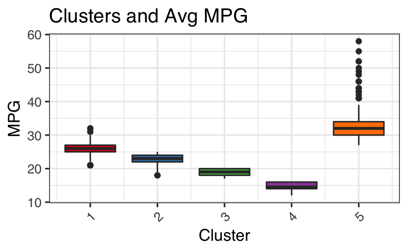

```r
ggplot(data, aes(x=k$cluster, y = comb08)) +
  geom_boxplot(aes(group = k$cluster, fill = as.factor(k$cluster)), show.legend = FALSE) +
  scale_fill_brewer(palette = "Set1") +
  labs(title = "Clusters and Avg MPG", x = "Cluster", y = "MPG")
```

```r
NA
```

## Conclusion

In conclusion, we can say that the automotive world is undergoing a sea change and these are exciting times, it remains to be seen which fuel types dominate in the coming years; it’s clear that Gasoline as a fuel has had a great run and is by no means done.